# Class 8: Aspects of Social Movement Activity

Social movement coalitions

[Dr. Michael C. Zeller](https://michaelzeller.de)

# Opening notes

[Open Sticker](https://tenor.com/view/open-gif-14209777)from [Open Stickers](https://tenor.com/search/open-stickers)

## Presentation groups

Presentations line-up

| Date | Presenters | Method |
| --- | --- | --- |
| 4 Dec: | Daichi, Seongyeon, Jehyun | ethnography |
| 18 Dec: | Ayla, Tara, Theresa, Annabelle | TBD |
| 15 Jan: | Luna, Emilene, Raffa, Sofia | TBD |

# Poll: SM coalitions opening questions

[figure not shown]

Take the survey at **https://forms.gle/qmXcNdhWNN3eNNPC8**

- are coalitions helpful to achieve goals?
- short-term, limited coalitions more likely to achieve goals?
- factor most important in facilitating coalition formation?
- most important benefit for a movement in forming a coalition?
- identity-based movements struggle more to form coalitions?

[interactive chart not shown]

Are coalitions helpful to achieve goals?

[interactive chart not shown]

What are the advantages and disadvantages for movements of forming a coalition/collaborating with other actors?

## Poll results - why coalition

short-term, limited coalitions more likely to achieve goals?

[interactive chart not shown]

most important benefit for a movement in forming a coalition?

[interactive chart not shown]

## Poll results - coalition how

**What factors enable/hinder coalition formation?**

## Poll results - coalition how

factor most important in facilitating coalition formation?

[interactive chart not shown]

identity-based movements struggle more to form coalitions?

[interactive chart not shown]

# Movement coalitions

- why make coalitions
- types of coalitions
- coalition formation
  - key factors
    - intra-/inter-organisational
  - examples: Memorial-Sakharov Centre; Raging Grannies
  - context (opportunities and threats)
- risks and outcomes

[Parks And GIF](https://tenor.com/view/parks-and-rec-april-moon-gif-13637117)from [Parks GIFs](https://tenor.com/search/parks-gifs)

## Why movements make coalitions

Coalitions…

- help build/enhance networks
- increase resource availability
  - boost mobilisation potential (again, networks)
- expand tactical repertoires

## Types of coalitions

Some coalitions may be enduring; others may be event coalitions

[figure not shown]

## Types of coalitions

Some coalitions may be enduring; others may be event coalitions

[figure not shown]

**Peace protest, Berlin, 2022-02-27**

## Coalition formation

Van Dyke and Amos (2017) identify five factors critical to coalition formation:

1. **social ties** - connections between organisations
2. **conducive organizational structures** - structures that enable collaboration
3. **ideology, culture, and identity** - shared ideas
4. **institutional environment** - opportunities and threats
5. **resources** - pooling resources or competing

## Coalition formation - intra-/inter-organisational factors

- ‘**exclusive affiliations**’ orgs. or ‘**multiple affiliations**’ orgs.
  - individuals with (other) social ties: ‘**coalition brokers**’ or ‘**bridge builders**’
- broad/multi-issue organisational goals = more likely to form coalition (e.g., Borland 2008)
  - fits with our discussion of framing (e.g., *bridging frames*)
- **strong organisation** (e.g., division of labour, professional leaders) = more likely to form coalition
  - e.g., well organised movements can send representatives to others’ meetings (Borland 2008)
  - non-hierarchical or loose organisations will struggle (e.g., OWS)
  - fits with discussion of orgs. in social media age (Tufekci 2017)

## Coalition formation - intra-/inter-organisational factors

[figure not shown]

[figure not shown]

- commonalities and connections between organisations
  - ‘plentiful resources and congruent ideologies’ (2015)
  - overlapping collective identities (e.g., Memorial and Sakharov Centre)
- ideological compatibility (a necessary condition?)
  - splits within movement (e.g., TERF vs. inclusive feminist groups) by ‘minor’ differences
  - others accommodate …

## Coalition formation - intra-/inter-organisational factors

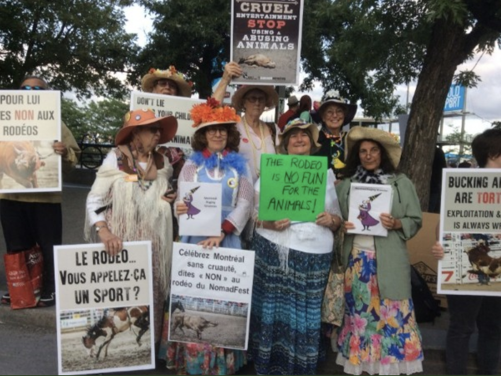

others accommodate, e.g., Raging Grannies: a rowdy aging women’s group in Canada that tempered its strategies to facilitate collaboration with indigenous environmental allies, creating space for indigenous activists at their gatherings, adopting mainstream dress, lending resources to Indigenous protests, and initiating action to ameliorate colonial abuses (Chazan 2016)

## Coalition formation - external social and political conditions

- related to **opportunity structures**
  - opportunities - *general or specific openings for mobilisation or movement activism*
    - e.g., northern Ireland civil rights groups found international partners in late 1960s partly due to generally high social mobilisation — access to others’/more/shared resources
  - threats:
    - e.g., government repression often drives organisations to collaborate (e.g., For Fair Elections movement in Russia)

## Coalition formed amid government repression

For Fair Elections (Russia, 2011-2012) - **strange bedfellows**

[figure not shown]

[figure not shown]

[figure not shown]

[figure not shown]

## Coalition formation - external social and political conditions

- related to **opportunity structures**
  - *institutional arrangements*:
    - Obach (2010) suggests that U.S. governmental separation of labor and environmental protection into two separate policy arenas inhibits collaboration of labor and environmental groups even when issues are of interest to both.
- **Free space** facilitates the organization of coalitions:

> settings within a community or movement that are removed from the direct control of dominant groups, are voluntarily participated in, and generate the cultural challenge that precedes or accompanies political mobilization” (Polletta, 1999: 1).

## Coalition formation - summary and ‘potential’

| Grouping | Factors |  |
| --- | --- | --- |
| Intra-org | exclusive vs. multiple affiliations | any bridging social ties? |
|  | broad organisational goals | e.g., bridging frames |
|  | strong organisation | division (and availability) of labour, professional leaders, (at least some) hierarchy |
| Inter-org | commonalities | available resources, overlapping collective identities |
|  | ideological compatibility | factions vs. willingness to accommodate |
| Opportunity structure | opportunities | free space |
|  | threats |  |
|  | institutional arrangements |  |

**What’s the coalition potential of movement cases you know of? Have they formed *enduring* and/or *event* coalitions?**

## Risks of coalition formation

- where there is *disparity*/*imbalance*…
  - **resource-rich** organisations may try to control **resource-poor** partner organisations

## Coalitions and movement outcomes (2015)

**radical flank effects** - dynamics between (relatively) moderate and (relatively) radical parts of a movement and their target(s)

- **positive radical flank effect** - activity of radical part of movement compels target/authorities to accept moderate demands
  - e.g., Martin Luther King Jr. and moderate NAACP made more appealing to U.S. (federal) government by presence of black nationalists and Malcolm X
- **negative radical flank effect** - activity of radical part of movement spooks potential elite allies
  - e.g., U.S. peace/student movement (late 1960s and 1970s) dominated by (radical) Youth International Party (‘Yippies’, Abby Hoffman and Jerry Rubin) more than (moderate) Students for a Democratic Society (SDS, Tom Hayden)

## Radical flanks and (non/violent) tactics (Chenoweth and Stephan 2011)

Pay attention to the mechanisms that Prof. Chenoweth specifies in her brief explanation

[video not shown]

## Radical flanks and (non/violent) tactics (Chenoweth and Stephan 2011)

Pay attention to the mechanisms that Prof. Chenoweth specifies in her brief explanation

- nonviolent campaigns are better at eliciting broad and diverse support
- nonviolent campaigns create more defections among the opposition
- nonviolent campaigns have a broader set of tactics at their disposal
- nonviolent campaigns often maintain discipline even in the face of escalating oppression

## Coalitions and movement outcomes (2015)

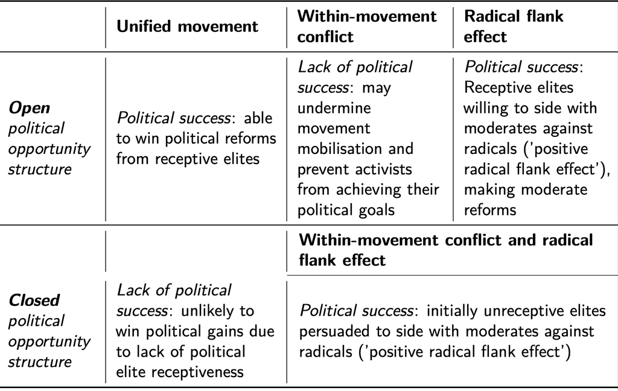

# Coalitions between parties and movements

- A. S. Heinze and Weisskircher (2022)
  - research questions
  - types of party responses
  - findings
- further questions

[Do You Want To Form An Alliance With Me GIF](https://tenor.com/view/do-you-want-to-form-an-alliance-with-me-alliance-the-office-jim-halpert-gif-13873405)from [Do You Want To Form An Alliance GIFs](https://tenor.com/search/do+you+want+to+form+an+alliance-gifs)

## A. S. Heinze and Weisskircher (2022) - RQ

**How have German political parties responded to anti-Corona street protests?**

**What do you recall from the height of the pandemic? How did parties (in Germany and elsewhere) respond to mobilisation?**

## Types of party responses

A. Heinze (2018) on **party reactions** to radical **parties** (somewhat compelled to react):

**Disengage**

1. ignore
2. legal restrictions
3. cordon sanitaire (blocking coalitions)
4. demonise
5. defuse
6. hold

**Engage**

7. adopt (co-opt) policies
8. collaborate (executive, legislative, electoral) [national, regional, local – e.g., cooperation with AfD at lower levels]

## Types of party responses

A. S. Heinze and Weisskircher (2022) on **party responses** to **movements** (not necessarily compelled to react):

- **dismissive**: ignore or disregard the movement
- **accommodative**: legitimate or even collaborate with the movement
- **adversarial**: oppose/challenge the movement

## Heinze and Weisskricher (2022) - response options

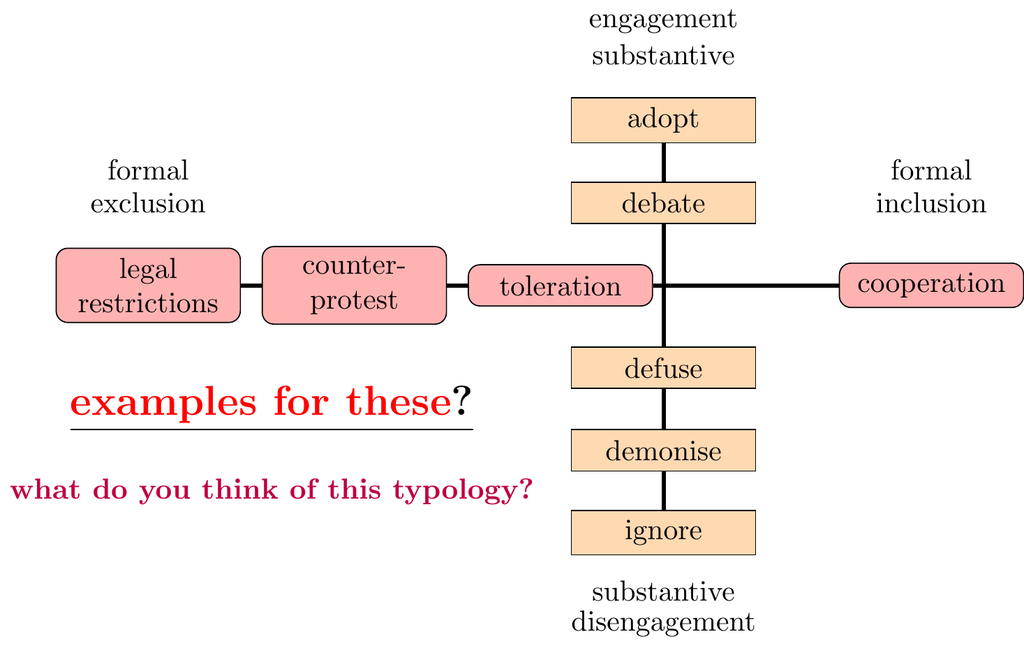

## Heinze and Weisskricher (2022) - response options

| Level | Action | Description |
| --- | --- | --- |
| Formal level | legal restrictions | most exclusionary possibility: e.g., bans, forced dissolution, event restrictions |
|  | counterprotest | parties can mobilise counterdemonstrations against pariah protest |
|  | tolerate | neutral acceptance of the right to protest, even for those that are regarded as pariahs; passive option |
|  | cooperate | act cooperatively with protest group; mobilise support base |
| Substantive level | ignore | disregard, refuse to comment on protest |
|  | demonise | portray the actor as extreme, dangerous, irrational, or beyond the pale |
|  | defuse | downplay protest issue importance, shift public attention to other issue(s) |
|  | debate | acknowledges the importance of an issue put forward by the protestors, with parties discussing different policy positions |
|  | adopt | adopting positions from protest arena becomes attractive if party considers the issue particularly relevant for competition, hoping to gain electoral advantage |

## Heinze and Weisskricher (2022) - findings

**Formal level - response to *Querdenken***

| Party | Legal Restrictions | Counterprotest | Tolerate | Cooperate |
| --- | --- | --- | --- | --- |
| CDU | Yes | No | Yes | No |
| SPD | Yes | Yes | Yes | No |
| Greens | Yes | Yes | Yes | No |
| Left | Yes | Yes | Yes | No |
| FDP | Yes | No | Yes | No |
| AfD | No | No | Yes | Yes |

**Substantive level - response to *Querdenken***

| Party | Ignore | Demonise | Defuse | Debate | Adopt |
| --- | --- | --- | --- | --- | --- |
| CDU | No | Yes | No | Yes | No |
| SPD | No | Yes | No | Yes | No |
| Greens | No | Yes | No | Yes | No |
| Left | No | Yes | No | Yes | No |
| FDP | No | Yes | No | Yes | No |
| AfD | No | Yes | No | Yes | Yes |

## Further questions

what about movement responses/approaches *to* parties?

(is it as relevant? does it matter? movements are not as *empowered* as parties)

is the epitome of social movement ‘success’ becoming a party?

# Any questions, concerns, feedback for this class?

Anonymous feedback here: https://forms.gle/AjHt6fcnwZxkSg4X8

Alternatively, please send me an email: m.zeller@lmu.de

## References

Allchorn, William. 2020. “Political Responses to Anti-Islamic Protest: Responses, Rationales and Role Evaluations.” *British Politics 15*: 393–410.

Chazan, M. (2016). Settler solidarities as praxis: Understanding ‘granny activism’ beyond the highly‐visible. *Social Movement Studies, 15*(5), 457–470.

Chenoweth, Erica, and Maria J. Stephan. 2011. *Why Civil Resistance Works: The Strategic Logic of Nonviolent Conflict*. New York: Columbia University Press.

Heinze, Anna Sophie, and Manès Weisskircher. 2022. “How Political Parties Respond to Pariah Street Protest: The Case of Anti-Corona Mobilisation in Germany.” *German Politics* 0 (0): 1–22. https://doi.org/10.1080/09644008.2022.2042518.

Heinze, Anna-sophie. 2018. “Strategies of Mainstream Parties Towards Their Right-Wing Populist Challengers: Denmark, Norway, Sweden and Finland in Comparison.” *West European Politics* 41 (2): 287–309. https://doi.org/10.1080/01402382.2017.1389440.

McCammon, Holly J, Erin M Bergner, and Sandra C Arch. 2015. “"Are You One of Those Women?" Within-movement Conflict, Radical Flank Effects, and Social Movement Political Outcomes.” *Mobilization: An International Quarterly* 20 (2): 157–78.

Tufekci, Zeynep. 2017. *Twitter and Tear Gas: The Power and Fragility of Networked Protest*. New Haven: Yale University Press.

Van Dyke, Nella, and Bryan Amos. 2017. “Social Movement Coalitions: Formation, Longevity, and Success.” *Sociology Compass* 11 (7): e12489. https://doi.org/10.1111/soc4.12489.